# Omy_Klamath_PCA

Kevin Olsen

2024-11-06

```r
library(kableExtra)
library(gt)
library(gtsummary)
library(knitr)
library(khroma)
library(adegenet)
library(tidyverse)
library(magrittr)
library(ggrepel)
```

Load quality filtered, location adjusted, and HWE/LD thinned markerset.

```r
load("C:/Users/olsenk2/OneDrive - Oregon State University/Desktop/Omy_klamath/Jan_2024_analyses/reproducible/Omykiss_Klamath_fullmarkerset_corrected_locations_Jan_2024_genos.R")
```

Update the location code name of Oak Hatchery to Klamath Hatchery.

```r
full_markerset %<>%
  mutate(location_code = case_when(location_code %in% c('OAKH') ~ 'KHAT',
         TRUE ~ as.character(location_code)
))
```

Revert the Omy-5 marker names to their original names (i.e., remove “Pearse” from the marker names).

```r
colnames(full_markerset)[95:100]<-c("OmyR14589", "OmyR19198", "OmyR24370", "OmyR33562", "OmyR40252", "OmyR40319")
```

Read in the metadata about marker. Filter the metadata to the markers that passed filtering.

```r
marker_mapping <- readxl::read_xlsx("C:/Users/olsenk2/OneDrive - Oregon State University/Desktop/Omykiss_Siletz_2023/Omy_GTseq_panel/final_mapping_results.xlsx", sheet = 1)

##filter mapping file to filtered markers in current panel##

marker_summary <- marker_mapping %>%
  mutate(marker = str_replace(marker, "Omy(\\d+)", "Chr\\1")) %>% # convert names to match
  filter(marker %in% colnames(full_markerset)) %>% # exclude filtered loci
  mutate(neutral = if_else(str_detect(`Presumed Type`, 'neutral|Neutral'), "neutral", "adaptive")) %>%
  mutate(run_timing = if_else(str_detect(`Presumed Type`, 'run|Run'), "run_timing", "non-run_timing")) %>%
  dplyr::select(marker, chr, start, 'Presumed Type', neutral, run_timing, Source)
```

Want to run principal components analysis (PCA) on adaptive markers (n = 105 markers), neutral markers (n = 193 markers), and the combined full markerset (n = 298 markers). Subset the adaptive markers.

```r
adaptive_marker_list<-subset(marker_summary, marker_summary$neutral == "adaptive")

##Make a list of marker columns to grab
to_grab<-which(colnames(full_markerset) %in% adaptive_marker_list$marker)

to_grab<-c(1:27, to_grab) #include sampling metadata in columns 1:27##

##adaptive markerset with adjusted locations and sex marker##
adaptive_markerset<-full_markerset[, to_grab]

##drop sex marker##
adaptive_markerset %<>%
  select(-one_of('OmyY1_2SEXY'))
```

subset the neutral markers.

```r
neutral_marker_list<-subset(marker_summary, marker_summary$neutral == "neutral")

##Make a list of marker columns to grab
nm<-which(colnames(full_markerset) %in% neutral_marker_list$marker)

to_grab<-c(1:27, nm) ##include sampling meta data in columns 1:27##

neutral_markerset<-full_markerset[, to_grab]
```

PCA with 193 neutral markers on the contemporary samples collected in the years 2015 - 2019 (Fig. 3a).

```r
##Filter samples collected in the years 2000, 2003, and 2006
contemp_neutral_markerset <- neutral_markerset %>%
  filter(! c(Year_Collected == "2000" | Year_Collected == "2003" | Year_Collected == "2006"))

##Replace dots in column names with underscores
colnames(contemp_neutral_markerset) <- gsub("\\.", "_", colnames(contemp_neutral_markerset))

##Set order of locations##
contemp_neutral_markerset$location_code<-factor(contemp_neutral_markerset$location_code, levels = unique(contemp_neutral_markerset$location_code))
```

Convert neutral dataframe to genind object for use in the R package ade4.

```r
neutral_matrix <- as.matrix(contemp_neutral_markerset[,c(28:(ncol(contemp_neutral_markerset)))]) ##create a matrix of just the genotype columns
row.names(neutral_matrix) <- contemp_neutral_markerset$sample_simple                                ##add sample names as rownames to the matrix
genind_1.0 <- df2genind(neutral_matrix, sep = "", ploidy = 2, NA.char = "0")                            ##convert to genind object
genind_1.0@pop <- as.factor(contemp_neutral_markerset$location_code)                                    ##set location code as identifying factor
```

Run PCA on sample groups (as opposed to running on individual samples).

```r
neutral_genpop <- genind2genpop(genind_1.0)    ##Condense the genind object from samples to sample groups
```

```
##
##  Converting data from a genind to a genpop object...
##
## ...done.
```

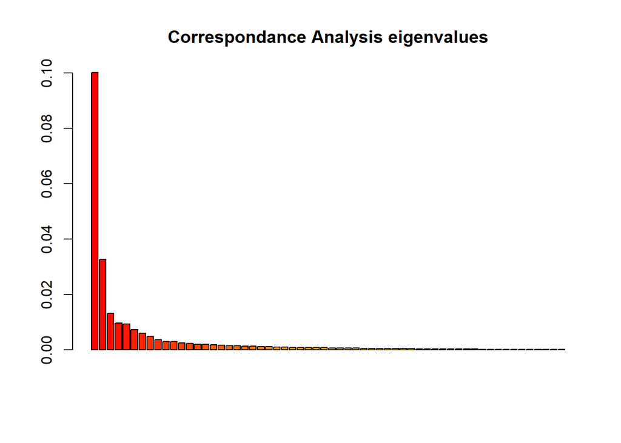

```r
PCA_neutral <- dudi.coa(as.data.frame(neutral_genpop$tab), scannf = FALSE, nf = 3)  ##run PCA evaluating 3 principal components

barplot(PCA_neutral$eig, main = "Correspondance Analysis eigenvalues", col = heat.colors(length(PCA_neutral$eig))) ##
```

Calculate percentage of total variation explained by each eigenvalue.

```r
eig.perc <- 100 * PCA_neutral$eig / sum(PCA_neutral$eig)
```

Grab principal components for each sampling location (pop).

```r
pop_pcs <- PCA_neutral$li

#create column of sample IDs from rownames##
pop_pcs %<>%
  rownames_to_column(var = "pop")

kable(pop_pcs[1:10, ])
```

| pop | Axis1 | Axis2 | Axis3 |
| --- | --- | --- | --- |
| JCNW | -0.3022651 | -0.0213678 | -0.0300552 |
| KENO | -0.2816105 | -0.1715285 | -0.0912805 |
| UKLA | 0.3505142 | -0.0559163 | 0.0123717 |
| FOST | 0.3937942 | -0.0485172 | 0.0546352 |
| SUNY | 0.3454638 | -0.0599635 | 0.0053531 |
| PEAR | -0.3134247 | -0.1508930 | -0.0717442 |
| WHIT | -0.0762181 | 0.2307759 | 0.0016533 |
| CHEW | -0.1923736 | 0.2940167 | -0.1531223 |
| BYPR | -0.3289954 | -0.1656082 | -0.0673797 |
| LJNY | -0.3112161 | -0.1091105 | -0.0779815 |

Read in basin, watershed, and life-history metadata for each sampling location. Note, this metadata has information for each sampling event, including those in the past (i.e., 2000, 2003, 2006). Drop the duplicate information for those locations with both past and contemporary sampling.

```r
lbls<-read.csv("C:/Users/olsenk2/OneDrive - Oregon State University/Desktop/Omy_klamath/Jan_2024_analyses/reproducible/Omykiss_Klamath_PCA_labels_Jan_2024.csv")

lbls %<>%
   distinct(collection_code, .keep_all = TRUE)   ##consolidate duplicate locations with past and contemporary sampling

kable(lbls[1:10, ])
```

| Basin | Watershed | collection_code | life_history |
| --- | --- | --- | --- |
| LKB | Trinity_River | HAYF | A |
| LKB | Trinity_River | SALT | A |
| LKB | Trinity_River | EFHF | A |
| LKB | Trinity_River | POTA | A |
| LKB | Trinity_River | RSCH | A |
| LKB | Trinity_River | ELTP | A |
| LKB | Trinity_River | JCNW | A |
| LKB | Trinity_River | GROU | A |
| LKB | Trinity_River | UDWD | A |
| LKB | Trinity_River | MOSQ | A |

Add the metadata to the PCA results with left_join.

```r
pop_pcs %<>%
  left_join(select(lbls, Basin, Watershed, collection_code, life_history), by = c("pop" = "collection_code"))

kable(pop_pcs[1:10, ])
```

| pop | Axis1 | Axis2 | Axis3 | Basin | Watershed | life_history |
| --- | --- | --- | --- | --- | --- | --- |
| JCNW | -0.3022651 | -0.0213678 | -0.0300552 | LKB | Trinity_River | A |
| KENO | -0.2816105 | -0.1715285 | -0.0912805 | UKB | Klamath_River | FLU |
| UKLA | 0.3505142 | -0.0559163 | 0.0123717 | UKB | Upper_Klamath_Lake | ADF |
| FOST | 0.3937942 | -0.0485172 | 0.0546352 | GB | Great_Basin | R |
| SUNY | 0.3454638 | -0.0599635 | 0.0053531 | UKB | Williamson_River | ADF |
| PEAR | -0.3134247 | -0.1508930 | -0.0717442 | UKB | Klamath_River | NA |
| WHIT | -0.0762181 | 0.2307759 | 0.0016533 | UKB | Sprague_River | R |
| CHEW | -0.1923736 | 0.2940167 | -0.1531223 | GB | Great_Basin | FLU |
| BYPR | -0.3289954 | -0.1656082 | -0.0673797 | UKB | Klamath_River | FLU |
| LJNY | -0.3112161 | -0.1091105 | -0.0779815 | UKB | Klamath_River | R |

Set order of watersheds and plot the PCA for the neutral marker set. Note, the plot created in this R markdown file is compressed. Exporting will make the plot larger and all the location labels will be visible.

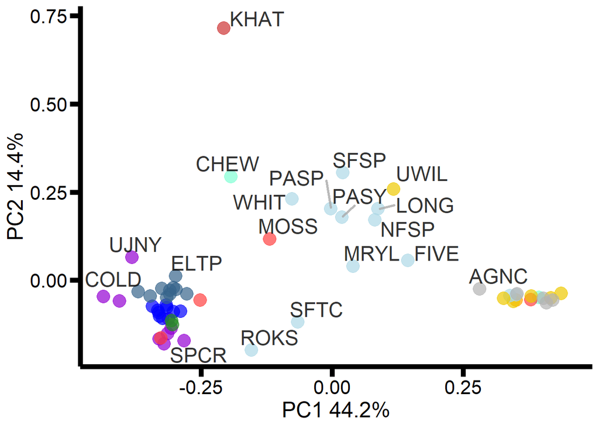

```r
pop_pcs$Watershed<-factor(pop_pcs$Watershed, levels = c('Trinity_River', 'Salmon_River', 'Lower_Klamath_River', 'Klamath_River', 'Upper_Klamath_Lake', 'KLCT', 'Wood_River', 'Williamson_River', 'Sprague_River', 'Great_Basin', 'Klamath_Hatchery'))

ggplot(pop_pcs)+
  geom_point(aes(Axis1, Axis2, color = Watershed), alpha = 0.7, size = 5.0)+
  scale_color_manual(labels = c("Trinity R.", "Salmon R.", "Mid - Klamath R.", "Upper - Klamath R.", "UKLA", "KLCT", "Wood R.", "Williamson R.", "Sprague R.", "Great Basin", "Klamath Hatchery"), values = c("steelblue4", "blue", "forestgreen", "darkviolet", "orange", "brown1", "grey70", "gold2", "lightblue", "aquamarine", "brown3"))+
  geom_text_repel(aes(x=Axis1, y=Axis2, label = pop), nudge_x = 0.015, nudge_y = 0.015, size = 6, alpha = 0.8, force = 6, max.overlaps = 15, min.segment.length = 0.8, segment.colour = "darkgrey", segment.size = 1) +
  xlab("PC1 44.2%")+
  ylab("PC2 14.4%")+
  theme(panel.background = element_blank(),
        text = element_text(family = "sans"),
        legend.position = "none",
        legend.title = element_text(size = 24, colour = "black"),
        legend.text = element_text(size = 20),
        axis.title = element_text(size = 18, colour = "black"),
        axis.line = element_line(size = 2, color = 'black'),
        axis.text.x = element_text(size = 16, colour = "black"),
        axis.text.y = element_text(size = 16, colour = 'black'),
        axis.ticks.x = element_line(size = 2, colour = "black"),
        axis.ticks.length.y = unit(0.3, "cm"),
        axis.ticks.length.x = unit(0.3, "cm"),
        axis.ticks.y = element_line(size = 2, color = 'black')
  )
```

PCA with both the neutral and adaptive markers (n = 298 markers) on the contemporary samples collected in the years 2015 - 2019 (Fig. 3c). Drop past collections.

```r
##drop old collections 2000 - 2006##
contemp_full_markerset <- full_markerset %>%
  filter(! c(Year_Collected == "2000" | Year_Collected == "2003" | Year_Collected == "2006"))

##Replace dots in column names with underscores
colnames(contemp_full_markerset) <- gsub("\\.", "_", colnames(contemp_full_markerset))

##Set order of locations##

contemp_full_markerset$location_code<-factor(contemp_full_markerset$location_code, levels = unique(contemp_full_markerset$location_code))
```

Convert genotype dataframe to genind object and set the sampling locations.

```r
#convert genotypes to matrix with individual samples as row names
full_matrix <- as.matrix(contemp_full_markerset[,c(28:(ncol(contemp_full_markerset)-1))])   ## -1 drops the sex marker in last column##
row.names(full_matrix) <- contemp_full_markerset$sample_simple
genind_full <- df2genind(full_matrix, sep = "", ploidy = 2, NA.char = "0")

#Set sampling locations
genind_full@pop <- as.factor(contemp_full_markerset$location_code)
```

Run PCA on sample groups (as opposed to running on individual samples).

```r
full_genpop <- genind2genpop(genind_full)
```

```
##
##  Converting data from a genind to a genpop object...
##
## ...done.
```

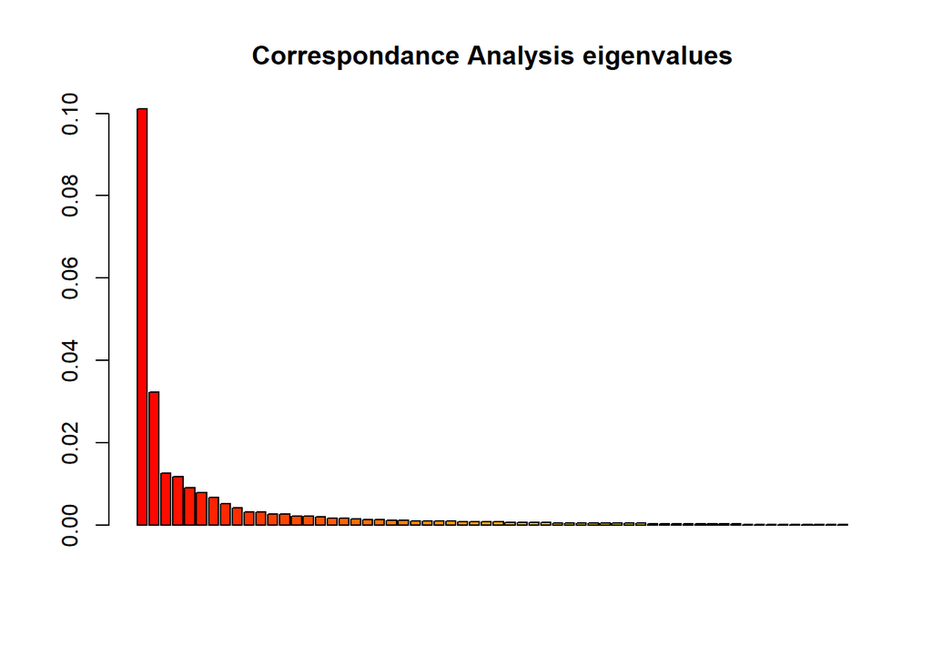

```r
PCA_full <- dudi.coa(as.data.frame(full_genpop$tab), scannf = FALSE, nf = 3)

barplot(PCA_full$eig, main = "Correspondance Analysis eigenvalues", col = heat.colors(length(PCA_full$eig)))
```

Calculate percentage of total variation explained by each eigenvalue.

```r
eig.perc <- 100 * PCA_full$eig / sum(PCA_full$eig)
```

Grab principal components for each sampling location (pop).

```r
pop_pcs <- PCA_full$li

#create column of sample IDs from rownames##
pop_pcs %<>%
  rownames_to_column(var = "pop")

kable(pop_pcs[1:10, ])
```

| pop | Axis1 | Axis2 | Axis3 |
| --- | --- | --- | --- |
| JCNW | -0.3177118 | 0.0233482 | -0.0451422 |
| KENO | -0.2837208 | -0.1606067 | -0.0353205 |
| UKLA | 0.3465800 | -0.0605980 | -0.0029383 |
| FOST | 0.3924926 | -0.0565194 | 0.0300754 |
| SUNY | 0.3486894 | -0.0691880 | -0.0032581 |
| PEAR | -0.3476830 | -0.1142032 | -0.0897296 |
| WHIT | -0.0692647 | 0.1977228 | 0.0084090 |
| CHEW | -0.2152198 | 0.3447757 | -0.0675371 |
| BYPR | -0.3526789 | -0.1593518 | -0.0721915 |
| LJNY | -0.3392208 | -0.1170048 | -0.0681490 |

Add the metadata to the PCA results with left_join.

```r
pop_pcs %<>%
  left_join(select(lbls, Basin, Watershed, collection_code, life_history), by = c("pop" = "collection_code"))

kable(pop_pcs[1:10, ])
```

| pop | Axis1 | Axis2 | Axis3 | Basin | Watershed | life_history |
| --- | --- | --- | --- | --- | --- | --- |
| JCNW | -0.3177118 | 0.0233482 | -0.0451422 | LKB | Trinity_River | A |
| KENO | -0.2837208 | -0.1606067 | -0.0353205 | UKB | Klamath_River | FLU |
| UKLA | 0.3465800 | -0.0605980 | -0.0029383 | UKB | Upper_Klamath_Lake | ADF |
| FOST | 0.3924926 | -0.0565194 | 0.0300754 | GB | Great_Basin | R |
| SUNY | 0.3486894 | -0.0691880 | -0.0032581 | UKB | Williamson_River | ADF |
| PEAR | -0.3476830 | -0.1142032 | -0.0897296 | UKB | Klamath_River | NA |
| WHIT | -0.0692647 | 0.1977228 | 0.0084090 | UKB | Sprague_River | R |
| CHEW | -0.2152198 | 0.3447757 | -0.0675371 | GB | Great_Basin | FLU |
| BYPR | -0.3526789 | -0.1593518 | -0.0721915 | UKB | Klamath_River | FLU |
| LJNY | -0.3392208 | -0.1170048 | -0.0681490 | UKB | Klamath_River | R |

Set order of watersheds and plot the PCA for the full marker set (i.e., neutral and adaptive markers). Note, the plot created in this R markdown file is compressed. Exporting will make the plot larger and all the location labels will be visible.

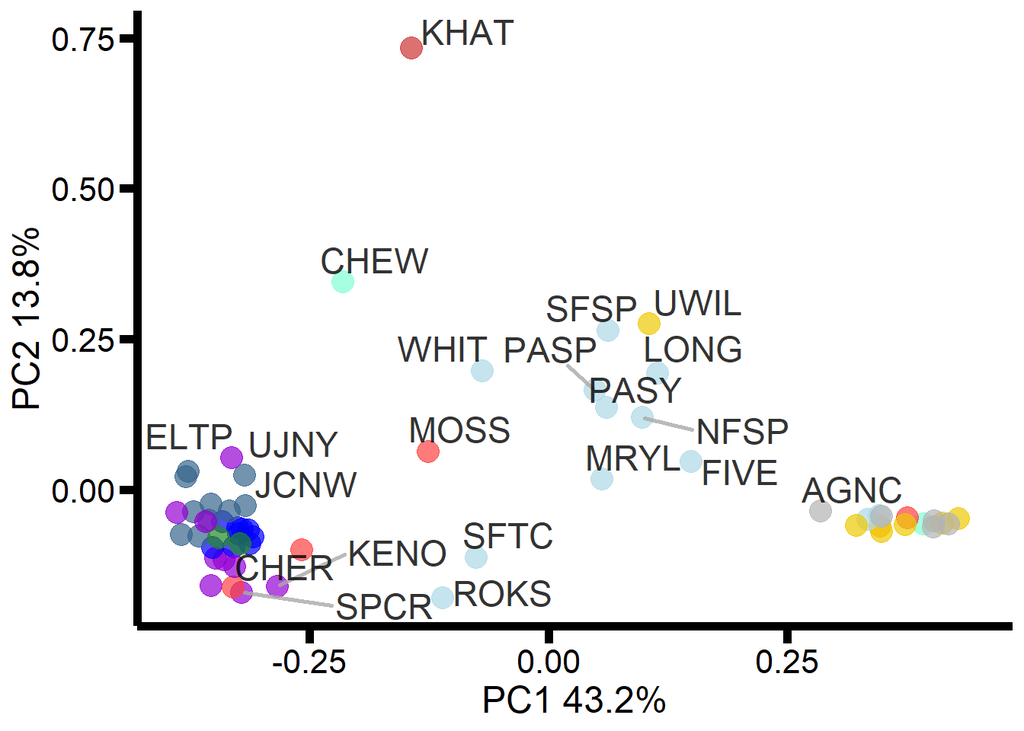

```r
pop_pcs$Watershed<-factor(pop_pcs$Watershed, levels = c('Trinity_River', 'Salmon_River', 'Lower_Klamath_River', 'Klamath_River', 'Upper_Klamath_Lake', 'KLCT', 'Wood_River', 'Williamson_River', 'Sprague_River', 'Great_Basin', 'Klamath_Hatchery'))

ggplot(pop_pcs)+
  geom_point(aes(Axis1, Axis2, color = Watershed), alpha = 0.7, size = 5.0)+
  scale_color_manual(labels = c("Trinity R.", "Salmon R.", "Lower Klamath R.", "Upper Klamath R.", "UKL", "KLCT", "Wood R.", "Williamson R.", "Sprague R.", "Great Basin", "Klamath Hatchery"), values = c("steelblue4", "blue", "forestgreen", "darkviolet", "orange", "brown1", "grey70", "gold2", "lightblue", "aquamarine", "brown3"))+
  geom_text_repel(aes(x=Axis1, y=Axis2, label = pop), nudge_x = 0.015, nudge_y = 0.015, size = 6, alpha = 0.8, force = 6, max.overlaps = 15, min.segment.length = 0.8, segment.colour = "darkgrey", segment.size = 1) +
  xlab("PC1 43.2%")+
  ylab("PC2 13.8%")+
  theme(panel.background = element_blank(),
        text = element_text(family = "sans"),
        legend.position = "none",
        legend.title = element_text(size = 24, colour = "black"),
        legend.text = element_text(size = 20),
        axis.title = element_text(size = 18, colour = "black"),
        axis.line = element_line(size = 2, color = 'black'),
        axis.text.x = element_text(size = 16, colour = "black"),
        axis.text.y = element_text(size = 16, colour = 'black'),
        axis.ticks.x = element_line(size = 2, colour = "black"),
        axis.ticks.length.y = unit(0.3, "cm"),
        axis.ticks.length.x = unit(0.3, "cm"),
        axis.ticks.y = element_line(size = 2, color = 'black')
  )
```

PCA with adaptive markers (n = 105 markers) on the contemporary samples collected in the years 2015 - 2019 (Fig. 3b). Drop past collections.

```r
##drop old collections 2000 - 2006##
contemp_adaptive_markerset <- adaptive_markerset %>%
  filter(! c(Year_Collected == "2000" | Year_Collected == "2003" | Year_Collected == "2006"))

##Replace dots in column names with underscores
colnames(contemp_adaptive_markerset) <- gsub("\\.", "_", colnames(contemp_adaptive_markerset))

##Set order of locations##
contemp_adaptive_markerset$location_code<-factor(contemp_adaptive_markerset$location_code, levels = unique(contemp_adaptive_markerset$location_code))
```

Convert genotype dataframe to genind object and set the sampling locations.

```r
adaptive_matrix <- as.matrix(contemp_adaptive_markerset[,c(28:(ncol(contemp_adaptive_markerset)))])
row.names(adaptive_matrix) <- contemp_adaptive_markerset$sample_simple
genind_adaptive <- df2genind(adaptive_matrix, sep = "", ploidy = 2, NA.char = "0")

##Set sampling locations
genind_adaptive@pop <- as.factor(contemp_adaptive_markerset$location_code)
```

Run PCA on sample groups (as opposed to running on individual samples).

```r
adaptive_genpop <- genind2genpop(genind_adaptive)
```

```
##
##  Converting data from a genind to a genpop object...
##
## ...done.
```

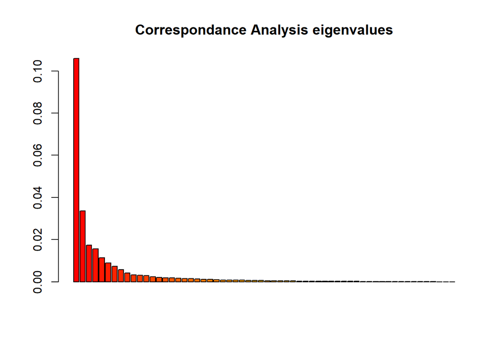

```r
PCA_adaptive <- dudi.coa(as.data.frame(adaptive_genpop$tab), scannf = FALSE, nf = 3)

barplot(PCA_adaptive$eig, main = "Correspondance Analysis eigenvalues", col = heat.colors(length(PCA_adaptive$eig)))
```

Calculate percentage of total variation explained by each eigenvalue.

```r
eig.perc <- 100 * PCA_adaptive$eig / sum(PCA_adaptive$eig)
```

Grab principal components for each sampling location (pop).

```r
pop_pcs <- PCA_adaptive$li

#create column of sample IDs from rownames##
pop_pcs %<>%
  rownames_to_column(var = "pop")

kable(pop_pcs[1:10, ])
```

| pop | Axis1 | Axis2 | Axis3 |
| --- | --- | --- | --- |
| JCNW | -0.3389408 | 0.1425213 | 0.1054829 |
| KENO | -0.2797697 | -0.1556283 | -0.0384994 |
| UKLA | 0.3389437 | -0.0570742 | 0.0225911 |
| FOST | 0.3894372 | -0.0597527 | 0.0252526 |
| SUNY | 0.3537093 | -0.0747755 | 0.0321243 |
| PEAR | -0.4087847 | -0.0370397 | 0.1207564 |
| WHIT | -0.0623657 | 0.1088990 | -0.1938010 |
| CHEW | -0.2561451 | 0.4153459 | -0.6987373 |
| BYPR | -0.3959161 | -0.1511816 | 0.0540870 |
| LJNY | -0.3892516 | -0.1381989 | 0.0423504 |

Add the metadata to the PCA results with left_join.

```r
pop_pcs %<>%
  left_join(select(lbls, Basin, Watershed, collection_code, life_history), by = c("pop" = "collection_code"))

kable(pop_pcs[1:10, ])
```

| pop | Axis1 | Axis2 | Axis3 | Basin | Watershed | life_history |
| --- | --- | --- | --- | --- | --- | --- |
| JCNW | -0.3389408 | 0.1425213 | 0.1054829 | LKB | Trinity_River | A |
| KENO | -0.2797697 | -0.1556283 | -0.0384994 | UKB | Klamath_River | FLU |
| UKLA | 0.3389437 | -0.0570742 | 0.0225911 | UKB | Upper_Klamath_Lake | ADF |
| FOST | 0.3894372 | -0.0597527 | 0.0252526 | GB | Great_Basin | R |
| SUNY | 0.3537093 | -0.0747755 | 0.0321243 | UKB | Williamson_River | ADF |
| PEAR | -0.4087847 | -0.0370397 | 0.1207564 | UKB | Klamath_River | NA |
| WHIT | -0.0623657 | 0.1088990 | -0.1938010 | UKB | Sprague_River | R |
| CHEW | -0.2561451 | 0.4153459 | -0.6987373 | GB | Great_Basin | FLU |
| BYPR | -0.3959161 | -0.1511816 | 0.0540870 | UKB | Klamath_River | FLU |
| LJNY | -0.3892516 | -0.1381989 | 0.0423504 | UKB | Klamath_River | R |

Set order of watersheds and plot the PCA for the adaptive marker set. Note, the plot created in this R markdown file is compressed. Exporting will make the plot larger and all the location labels will be visible.

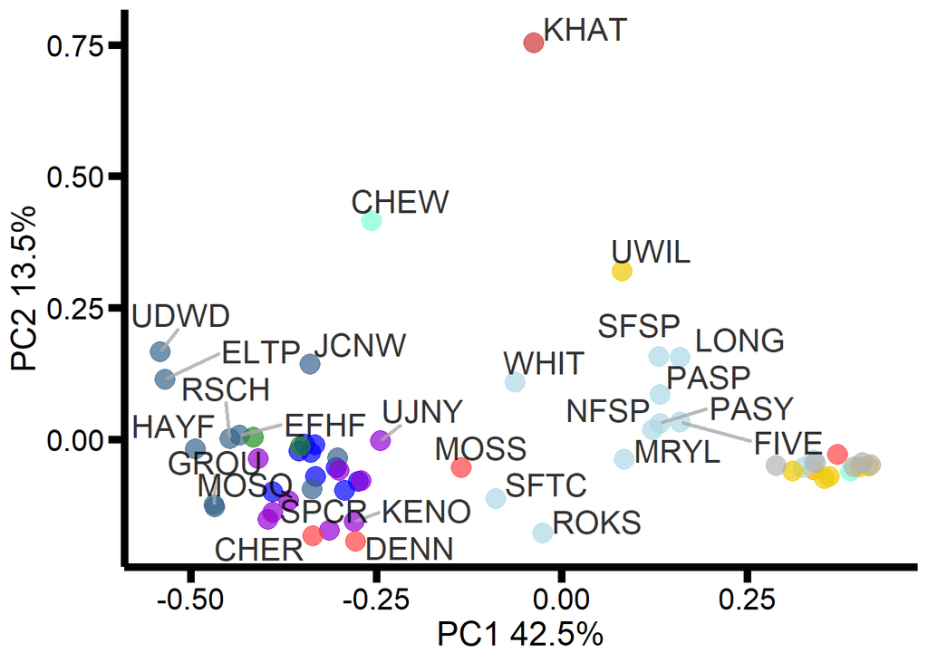

```r
pop_pcs$Watershed<-factor(pop_pcs$Watershed, levels = c('Trinity_River', 'Salmon_River', 'Lower_Klamath_River', 'Klamath_River', 'Upper_Klamath_Lake', 'KLCT', 'Wood_River', 'Williamson_River', 'Sprague_River', 'Great_Basin', 'Klamath_Hatchery'))

ggplot(pop_pcs)+
  geom_point(aes(Axis1, Axis2, color = Watershed), alpha = 0.7, size = 5.0)+
  scale_color_manual(labels = c("Trinity R.", "Salmon R.", "Lower Klamath R.", "Upper Klamath R.", "UKL", "KLCT", "Wood R.", "Williamson R.", "Sprague R.", "Great Basin", "Klamath Hatchery"), values = c("steelblue4", "blue", "forestgreen", "darkviolet", "orange", "brown1", "grey70", "gold2", "lightblue", "aquamarine", "brown3"))+
  geom_text_repel(aes(x=Axis1, y=Axis2, label = pop), nudge_x = 0.015, nudge_y = 0.015, size = 6, alpha = 0.8, force = 6, max.overlaps = 15, min.segment.length = 0.8, segment.colour = "darkgrey", segment.size = 1) +
  xlab("PC1 42.5%")+
  ylab("PC2 13.5%")+
  theme(panel.background = element_blank(),
        text = element_text(family = "sans"),
        legend.position = "none",
        legend.title = element_text(size = 24, colour = "black"),
        legend.text = element_text(size = 20),
        axis.title = element_text(size = 18, colour = "black"),
        axis.line = element_line(size = 2, color = 'black'),
        axis.text.x = element_text(size = 16, colour = "black"),
        axis.text.y = element_text(size = 16, colour = 'black'),
        axis.ticks.x = element_line(size = 2, colour = "black"),
        axis.ticks.length.y = unit(0.3, "cm"),
        axis.ticks.length.x = unit(0.3, "cm"),
        axis.ticks.y = element_line(size = 2, color = 'black')
  )
```